# ExamenBioinformatica_2022_AlvaroMartinLozano

Álvaro Martín Lozano

1/31/2022

# **EXAMEN BIOINFORMÁTICA MIDI 2022**

### **EJERCICIO 1**: Comandos de Linux

**¿Cuántas palabras hay en el fichero?** *Comando* -> wc genes.txt

EL segundo valor que devuelve esta función corresponde con el número total de palabras (podemos contar palabras de una misma línea porque están separadas por tabulados).

**¿Cómo cambiarías todos los tabulados por guiones?** *Comando* -> cat genes.txt | sed ‘s/-/g/’

El comando sed nos permite cambiar caracteres o separadores por otros que queramos. La “g” del final indica que se aplique dicho comando de forma general, a todos los tabulados que aparecen.

**¿Cómo cambiarías solo la primera aparición?** *Comando* -> cat genes.txt | sed ‘s/-/’

De esta forma, al no incluir el argumento “g”, se aplicará solamente a las primeras apariciones del tabulado en cada línea.

**¿Cómo buscarías todos los genes excepto el gen llamado DSTYK?** *Comando* -> cat genes.txt | grep -v DSTYK

Añadiendo el argumento “-v”, nos mostrará todos los genes menos DSTYK.

## DataSet “Weather”

Primero cargamos los paquetes necesarios y creamos un data frame con los datos de weather:

```r
library(tidyverse)
library(nycflights13)
clima <- nycflights13::weather
```

### **EJERCICIO 2**: Preguntas básicas

#### **Ej. 2A**: Columnas y registros del dataset

```r
print(paste0("Este dataset tiene: ", ncol(clima), " columnas."))
```

```
## [1] "Este dataset tiene: 15 columnas."
```

```r
print(paste0("Este dataset tiene: ", nrow(clima), " registros."))
```

```
## [1] "Este dataset tiene: 26115 registros."
```

#### **Ej. 2B**: “Origin” diferentes y número de registros de cada uno

Este data set tiene 3 areopuertos de origen (“origin”) diferentes (EWR, JFK y LGA), cada uno de los cuales contiene el número de registros que se indica a continuación:

```r
table(clima$origin)
```

```
##
##  EWR  JFK  LGA
## 8703 8706 8706
```

#### **Ej. 2C**: Mediana y Media de distintas variables del aeropuerto LGA

```r
mediana_speed <- median(clima$wind_speed[clima$origin=="LGA"], na.rm=T)
media_pressure <- mean(clima$pressure[clima$origin=="LGA"], na.rm=T)
print(paste0("En LGA, la mediana de 'wind_speed' fue: ", mediana_speed))
```

```
## [1] "En LGA, la mediana de 'wind_speed' fue: 10.35702"
```

```r
print(paste0("En LGA, la media de 'preassure' fue: ", media_pressure))
```

```
## [1] "En LGA, la media de 'preassure' fue: 1017.67816091954"
```

#### **Ej. 2D**: Calcular para cada mes la media de “wind_speed” y “wind_gust”, y el número de casos

Primero eliminamos los NA de la columna “wind_gust”, creando un nuevo data frame (“clima_complete”), con el que trabajaremos de aquí en adelante. Comprobamos antes y después de dicha operación que se han eliminado los 20778 NA que aparecían al principio.

```r
table(is.na(clima$wind_gust))
```

```
##
## FALSE  TRUE
##  5337 20778
```

```r
clima_complete <- clima[!is.na(clima$wind_gust),]
table(is.na(clima_complete$wind_gust))
```

```
##
## FALSE
##  5337
```

Creo un “for” para que, para cada mes, me calcule los mismos 3 parámetros pedidos, y los muestre por pantalla:

```r
for (mes in 1:12)
{
  media_gust <- mean(clima_complete$wind_gust[clima_complete$month==mes])
  print(paste0("La ráfaga de viento media en el mes ", month.name[mes], " es: ", media_gust))
  media_speed <- mean(clima_complete$wind_speed[clima_complete$month==mes], na.rm=T)
  print(paste0("La velocidad del viento media en el mes ", month.name[mes], " es: ", media_speed))
  casos <- table(clima_complete$month[clima_complete$month==mes])
  print(paste0("El total de casos en el mes ", month.name[mes], " es: ", casos))
  print(" ")
}
```

```
## [1] "La ráfaga de viento media en el mes January es: 27.4918115514019"
## [1] "La velocidad del viento media en el mes January es: 18.3759131588785"
## [1] "El total de casos en el mes January es: 535"
## [1] " "
## [1] "La ráfaga de viento media en el mes February es: 28.1565028104575"
## [1] "La velocidad del viento media en el mes February es: 19.3789847712418"
## [1] "El total de casos en el mes February es: 612"
## [1] " "
## [1] "La ráfaga de viento media en el mes March es: 26.2334414339623"
## [1] "La velocidad del viento media en el mes March es: 17.7191169559748"
## [1] "El total de casos en el mes March es: 795"
## [1] " "
## [1] "La ráfaga de viento media en el mes April es: 25.5682752233677"
## [1] "La velocidad del viento media en el mes April es: 17.0580396219931"
## [1] "El total de casos en el mes April es: 582"
```

[output cut: 33 more lines]

### **EJERCICIO 3**: Plots

#### **Ej. 3A**: Construir los plots

Primero, para poder trabajar de forma independiente con los datos de cada aeropuerto, creo 3 nuevas data frame, una para cada aeropuerto de origen (“origin”):

```r
clima_EWR <- clima_complete[clima_complete$origin=="EWR",]
clima_JFK <- clima_complete[clima_complete$origin=="JFK",]
clima_LGA <- clima_complete[clima_complete$origin=="LGA",]
```

A continuación, represento la distribución de la temperatura en cada mes, para cada aeropuerto.

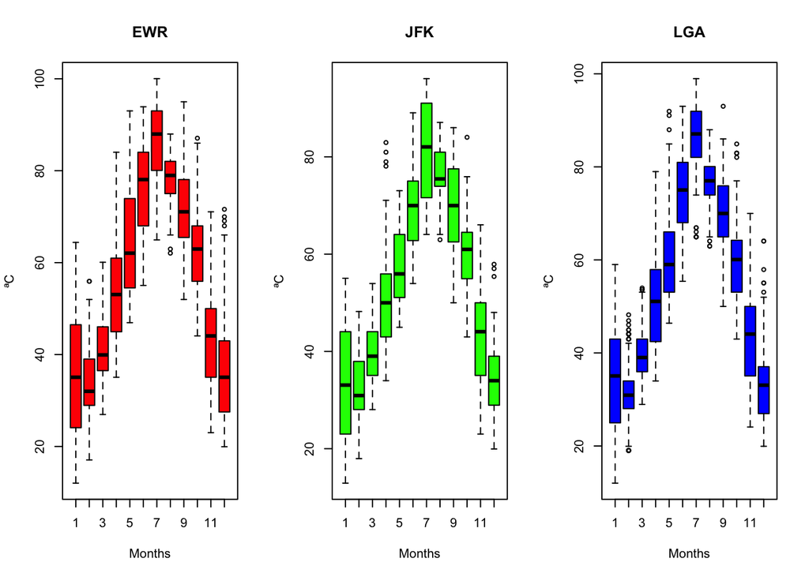

```r
par(mfrow=c(1,3))
boxplot(clima_EWR$temp ~ clima_EWR$month,
     main="EWR", xlab="Months", ylab="ªC", col="red")
boxplot(clima_JFK$temp ~ clima_JFK$month,
     main="JFK", xlab="Months", ylab="ªC", col="green")
boxplot(clima_LGA$temp ~ clima_LGA$month,
     main="LGA", xlab="Months", ylab="ªC", col="blue")
```

```r
par(mfrow=c(1,1))
```

Como podemos observar, en los tres aeropuertos se alcanzan temperaturas máximas en los meses de verano.

#### **Ej. 3B**: Función para reproducir los plots

```r
plot_meteo <- function(data,meteo,titulo,unidades)
{
  boxplot(meteo ~ data$month,
          main=titulo, xlab="Months", ylab=unidades, col="red")
  media <- c(mean(clima_EWR$temp,na.rm=T), mean(clima_LGA$temp,na.rm=T), mean(clima_JFK$temp,na.rm=T))
  return(media)
  print(media)
}
```

Prueba de la función, con los distintos datasets de los 3 “origins”:

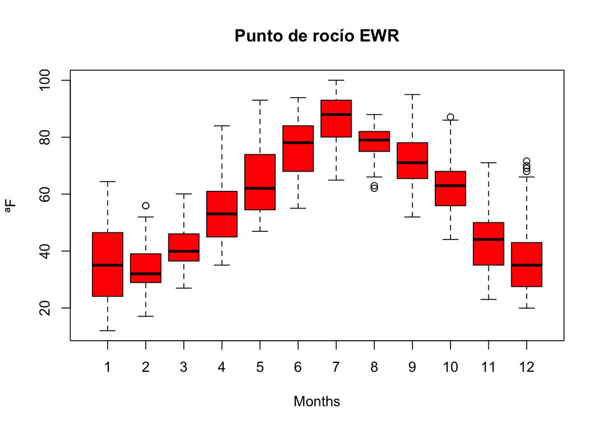

```
## [1] 54.23659 49.99077 47.46638
```

```r
plot_meteo(clima_EWR, clima_EWR$temp, "Punto de rocío EWR", "ªF")
```

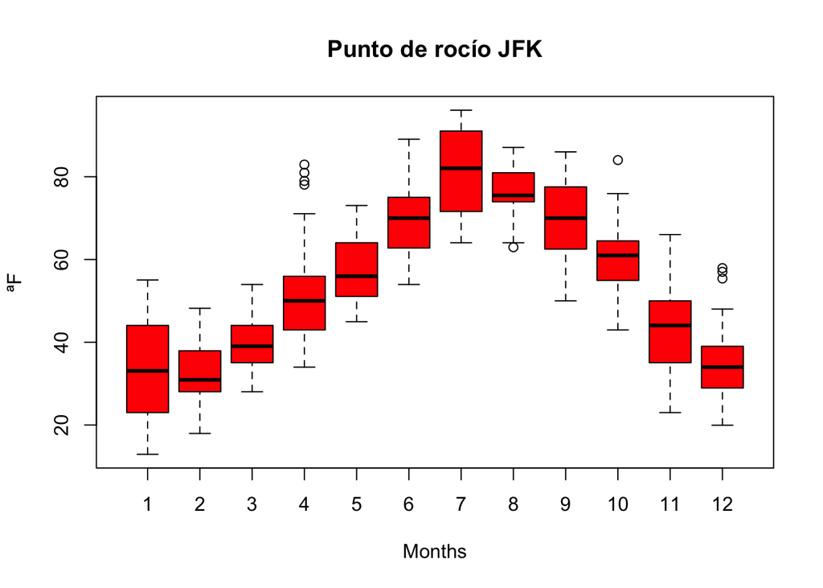

```
## [1] 54.23659 49.99077 47.46638
```

```r
plot_meteo(clima_JFK, clima_JFK$temp, "Punto de rocío JFK", "ªF")
```

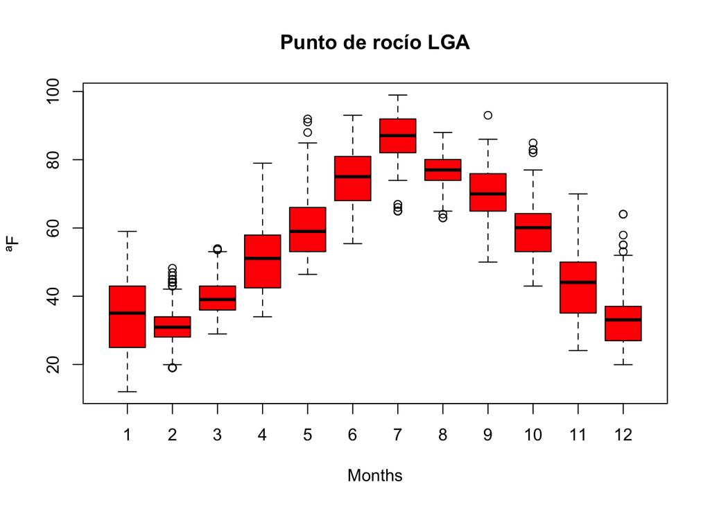

```
## [1] 54.23659 49.99077 47.46638
```

```r
plot_meteo(clima_LGA, clima_LGA$temp, "Punto de rocío LGA", "ªF")
```

Otra prueba con la función; en este caso, con la variable “humid” (humedad):

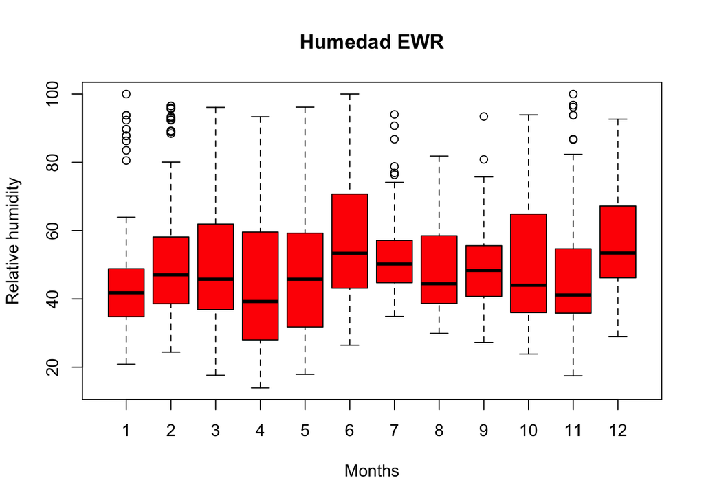

```
## [1] 54.23659 49.99077 47.46638
```

```r
plot_meteo(clima_EWR, clima_EWR$humid, "Humedad EWR", "Relative humidity")
```

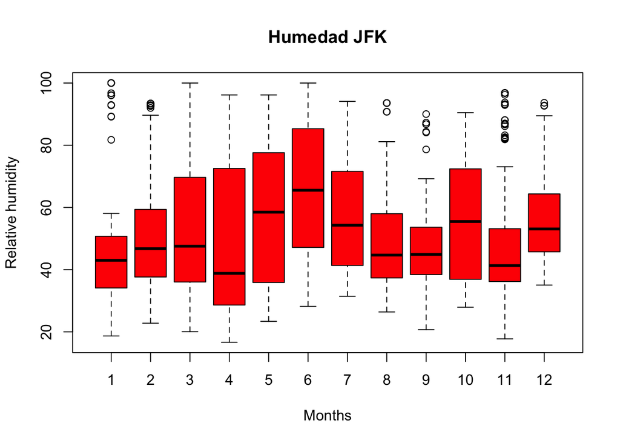

```
## [1] 54.23659 49.99077 47.46638
```

```r
plot_meteo(clima_JFK, clima_JFK$humid, "Humedad JFK", "Relative humidity")
```

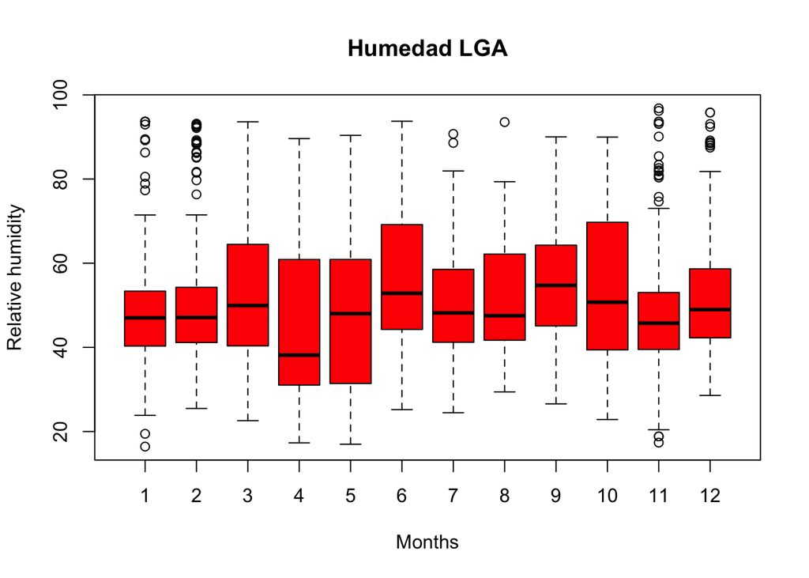

```
## [1] 54.23659 49.99077 47.46638
```

```r
plot_meteo(clima_LGA, clima_LGA$humid, "Humedad LGA", "Relative humidity")
```

### **EJERCICIO 4**: El día de mi cumpleaños:

Si bien el día de mi cumpleaños es el 16 de agosto, he escogido la fecha deñ 14 de agosto por ser una que tenía suficientesdatos recogidos para los tres aeropuertos.

#### **Ej. 4A**: Relación entre la temperatura y la humedad en cada uno de los origins:

Para el aeropuerto (“origin”) **EWR**:

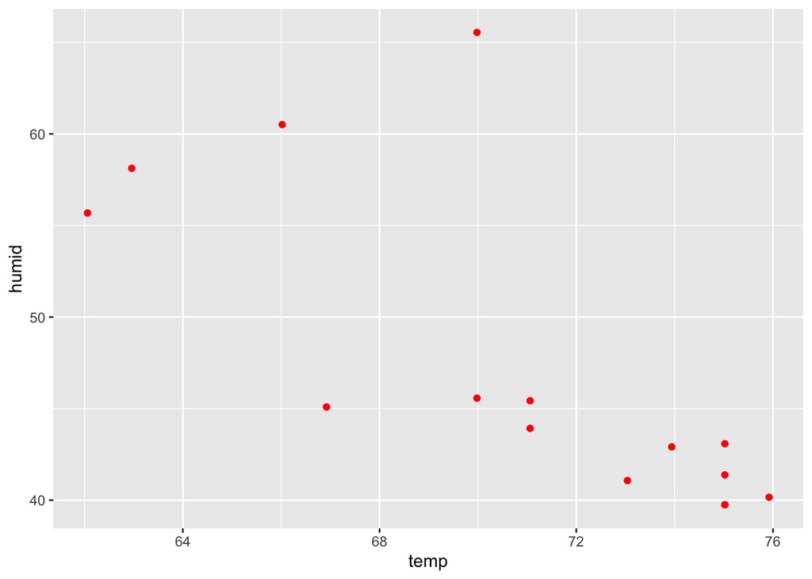

```r
clima_EWR_cumple <- clima_EWR[clima_EWR$month==8 & clima_EWR$day==14,]
ggplot(data=clima_EWR_cumple) +
  geom_point(mapping = aes(x=temp, y=humid), col="red")
```

```r
#Test de correlación
cor.test(clima_EWR_cumple$temp, clima_EWR_cumple$humid)
```

```
##
##  Pearson's product-moment correlation
##
## data:  clima_EWR_cumple$temp and clima_EWR_cumple$humid
## t = -3.9997, df = 13, p-value = 0.001513
## alternative hypothesis: true correlation is not equal to 0
## 95 percent confidence interval:
##  -0.9091133 -0.3720538
## sample estimates:
##        cor
## -0.7427554
```

El test de correlación empleado (para ver la correlación estadística entr las variables temperatura y humedad) nos devuelve un **p-value < 0.05**, lo que indica que sí se encuentra una relación significativa entre ambas variables. Concretamente, si observamos el Scatterplot generado, ppodemos visualizar una tendencia a disminuir la humedad conforme aumenta la temperatura (excepto a algunos outliers).

Para el aeropuerto (“origin”) **JFK**:

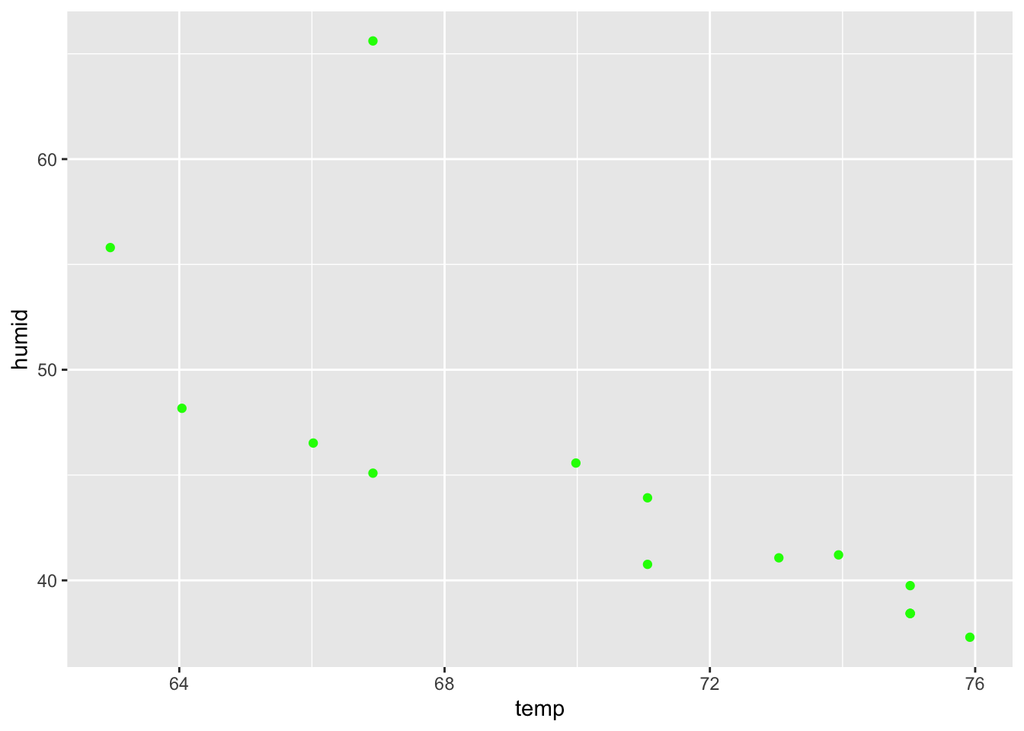

```r
clima_JFK_cumple <- clima_JFK[clima_JFK$month==8 & clima_JFK$day==14,]
ggplot(data=clima_JFK_cumple) +
  geom_point(mapping = aes(x=temp, y=humid), col="green")
```

```r
#Test de correlación
cor.test(clima_JFK_cumple$temp, clima_JFK_cumple$humid)
```

```
##
##  Pearson's product-moment correlation
##
## data:  clima_JFK_cumple$temp and clima_JFK_cumple$humid
## t = -4.2891, df = 13, p-value = 0.0008809
## alternative hypothesis: true correlation is not equal to 0
## 95 percent confidence interval:
##  -0.9178298 -0.4165352
## sample estimates:
##        cor
## -0.7654663
```

En este caso, el test de correlción nos devuelve un **p-value << 0.05**, más pequeño que en el caso anterior, lo que nos muestra una fuerte asociación significativa entre las variables temperatura y humedad en este aeropuerto de JFK. Además, al observar el Scatterplot, se visualiza con mayor facilidad esta asociación de disminución de la humedad con el aumento de la temperatura.

Para el aeropuerto (“origin”) **LGA**:

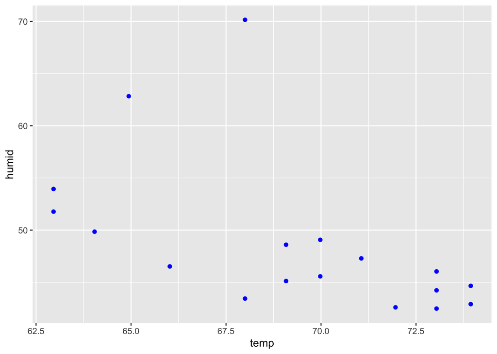

```r
clima_LGA_cumple <- clima_LGA[clima_LGA$month==8 & clima_LGA$day==14,]
ggplot(data=clima_LGA_cumple) +
  geom_point(mapping = aes(x=temp, y=humid), col="blue")
```

```r
#Test de correlación
cor.test(clima_LGA_cumple$temp, clima_LGA_cumple$humid)
```

```
##
##  Pearson's product-moment correlation
##
## data:  clima_LGA_cumple$temp and clima_LGA_cumple$humid
## t = -2.551, df = 16, p-value = 0.02136
## alternative hypothesis: true correlation is not equal to 0
## 95 percent confidence interval:
##  -0.80299576 -0.09458519
## sample estimates:
##        cor
## -0.5377105
```

Como la temperatura es una variable numérica, puedo realizar un T de Student (test estadístico) para comparar las medias de temperatura de dos grupos: los aeropuertos LGA y JFK.

```r
t.test(clima_LGA_cumple$temp, clima_JFK_cumple$temp)
```

```
##
##  Welch Two Sample t-test
##
## data:  clima_LGA_cumple$temp and clima_JFK_cumple$temp
## t = -1.1285, df = 27.584, p-value = 0.2688
## alternative hypothesis: true difference in means is not equal to 0
## 95 percent confidence interval:
##  -4.579496  1.327496
## sample estimates:
## mean of x mean of y
##    69.170    70.796
```

Vemos que el t-test nos devuelve un **p-value >> 0.05**, lo que indica que no hay diferencias estadísticamente significativas entre las temperaturas de ambos aeropuertos el día 14 de agosto. Para corroborar esta información estadística, podemos representar los boxplots de la dispersión de la temperatura en ambos aeropuertos aquel día.

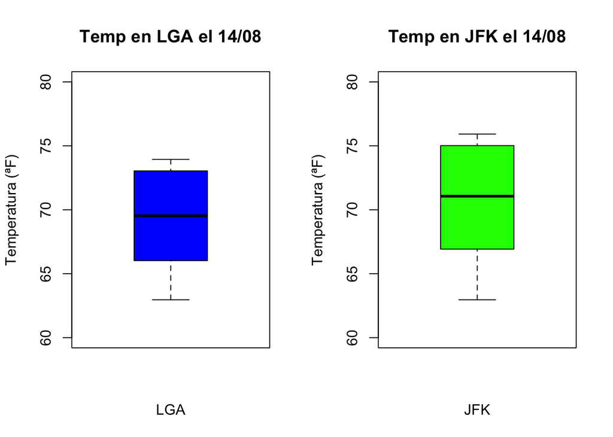

```r
par(mfrow=c(1,2))
boxplot(clima_LGA_cumple$temp ~ clima_LGA_cumple$origin,
        main="Temp en LGA el 14/08", xlab="LGA", ylab="Temperatura (ªF)",
        col="blue", ylim=c(60,80))
boxplot(clima_JFK_cumple$temp ~ clima_JFK_cumple$origin,
        main="Temp en JFK el 14/08", xlab="JFK", ylab="Temperatura (ªF)",
        col="green", ylim=c(60,80))
```

```r
par(mfrow=c(1,1))
```

Podemos comprobar, al comparar amobs boxplots, que apenas hay diferencias en la dispersión de las temperaturas, presentando ambos medianas (y valores de máximos y mínimos) muy similares. Solo el aeropuerto de JFK tendría uaa ligera mayor temperatura máxima registrada aquel día.

### **URL de GitHub**

Pincha [aquí](https://github.com/alvaromlz/ExamenBioinformatica_2022_AlvaroMartin.git) para dirigirse al proyecto online compartido en GitHub del Examen.